# IODS course project

### Are assumptions met in our model?

#### running a test for normality

I still want to run a test to check for normality, because interpreting the figures was a bit difficult. I use the function in below chunk that makes 4 tests for normality of the residuals. If p value is small it indicates non-normal distribution. I will use Kolmogorov-Smirnov p-value, because we have more than 50 observations (if less then I should use Shapiro test).

```r
library("olsrr")
ols_test_normality(m2)
```

```
## -----------------------------------------------
##        Test             Statistic       pvalue
## -----------------------------------------------
## Shapiro-Wilk              0.9739         0.0032
## Kolmogorov-Smirnov        0.0619         0.5479
## Cramer-von Mises         11.4711         0.0000
## Anderson-Darling          0.7013         0.0659
## -----------------------------------------------
```

High p-value in Kolmogorov-Smirnov test (0.5479) indicates that the **residuals are normally distributed**.

#### Checking for independence

We do not use any plot to test for the independence, but rather deduce this from the experimental setup. Since this was not a longitudinal data and there is no other aspect of the setup to question the independence of the measurements, I will determine that the **independence of residuals assumption is met**.

# Chapter 3: logistic regression

## The data

The data contains student achievement in secondary education of two Portuguese schools. The data attributes include student grades, demographic, social and school related features, as well as the alcohol use data, and it was collected by using school reports and questionnaires. Two datasets are provided regarding the performance in two distinct subjects: Mathematics (mat) and Portuguese language (por).

More information of the original data from: https://www.archive.ics.uci.edu/dataset/320/student+performance

### the modified data

The joined data set used in the analysis combines the two student alcohol consumption data sets. The following adjustments have been made:

- The variables not used for joining the two data have been combined by averaging (including the grade variables)
- ‘alc_use’ is the average of ‘Dalc’ and ‘Walc’
- ‘high_use’ is TRUE if ‘alc_use’ is higher than 2 and FALSE otherwise
- more info of how the data was created from the original data in: https://github.com/lehakkin/IODS-project/blob/master/data/create_learning2014.R

### get the data

```r
setwd("\\\\ad.helsinki.fi\\home\\l\\lehakkin\\Desktop\\KURSSIT\\Open_Data_Science\\IODS-project\\data")

alc <- read.csv2(file = "alc.csv")

names(alc)
```

```
##  [1] "school"     "sex"        "age"        "address"    "famsize"
##  [6] "Pstatus"    "Medu"       "Fedu"       "Mjob"       "Fjob"
## [11] "reason"     "guardian"   "traveltime" "studytime"  "schoolsup"
## [16] "famsup"     "activities" "nursery"    "higher"     "internet"
## [21] "romantic"   "famrel"     "freetime"   "goout"      "Dalc"
## [26] "Walc"       "health"     "failures"   "paid"       "absences"
## [31] "G1"         "G2"         "G3"         "alc_use"    "high_use"
```

```r
# get the packages
# access the tidyverse libraries tidyr, dplyr, ggplot2
library(tidyr); library(dplyr); library(ggplot2)
```

## Hypothesis of alcohol consumption

I will model high/low alcohol usage with these 4 explanatoryvariables:

- activities - extra-curricular activities (binary: yes or no)
- goout - going out with friends (numeric: from 1 - very low to 5 - very high)
- sex - student’s sex (binary: ‘F’ - female or ‘M’ - male)
- age - student’s age (numeric: from 15 to 22)

The hypothesis behind using these explanatory variables are:

- **age** affects alcohol usage because of the legal status to drink alcohol changes between the 15 and 22
- **going out** affects alcohol usage in cases where alcohol consumption is a social event
- **sex** affects alcohol usage, so that males typically consume more alcohol
- **activities** affect alcohol usage by limiting time for alcohol usage

## Data distribution and relationship

#### View of the data

##### Distributions

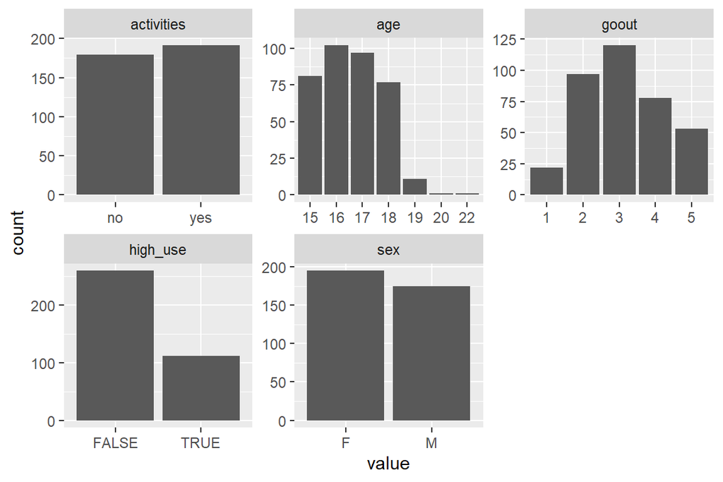

```r
model_var <- c("high_use", "sex", "age", "activities", "goout")

# use gather() to gather columns into key-value pairs and then glimpse() at the resulting data
alc %>% select(all_of(model_var)) %>% gather() %>% ggplot(aes(value)) + geom_bar() + facet_wrap("key", scales = "free")
```

- **Distributions** look ok (goout is normally distributed, activities and sex have similar counts for each group), otherwise than for *age* which is *right-skewed*

#### Numerical distributions

```r
# produce summary statistics by group
alc %>% group_by(sex) %>% summarise(count = n())
```

```
## # A tibble: 2 × 2
##   sex   count
##   <chr> <int>
## 1 F       195
## 2 M       175
```

```r
alc %>% group_by(age) %>% summarise(count = n())
```

```
## # A tibble: 7 × 2
##     age count
##   <int> <int>
## 1    15    81
## 2    16   102
## 3    17    97
## 4    18    77
## 5    19    11
## 6    20     1
## 7    22     1
```

```r
alc %>% group_by(activities) %>% summarise(count = n())
```

```
## # A tibble: 2 × 2
##   activities count
##   <chr>      <int>
## 1 no           179
## 2 yes          191
```

```r
alc %>% group_by(goout) %>% summarise(count = n())
```

```
## # A tibble: 5 × 2
##   goout count
##   <int> <int>
## 1     1    22
## 2     2    97
## 3     3   120
## 4     4    78
## 5     5    53
```

##### explanatory vs dependet

```r
library("ggpubr")
table(alc$high_use, alc$activities, alc$sex)
```

```
## , ,  = F
##
##
##         no yes
##   FALSE 80  74
##   TRUE  24  17
##
## , ,  = M
##
##
##         no yes
##   FALSE 40  65
##   TRUE  35  35
```

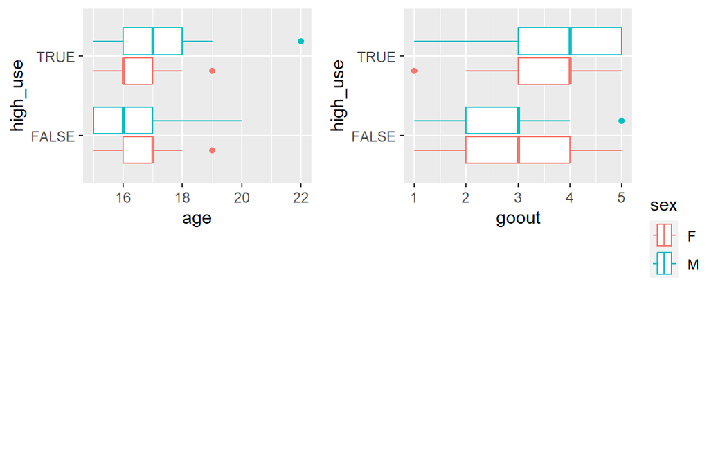

```r
# Box plots
g1 <- ggplot(alc, aes(x = age , y = high_use, col = sex)) + geom_boxplot()
g2 <- ggplot(alc, aes(x = goout, y = high_use, col = sex)) + geom_boxplot()


comb <- ggarrange(g1, g2,
                    ncol = 2, nrow = 2, common.legend = TRUE, legend="right")
comb
```

Looks like - activities correlates weakly with high_use status overall, and the effect is somewhat different for male and female - age and high_use status is opposite to male and female: the median age for female without high_use status is 17 and with high_use status 16, while for male it is the opposite - goout seems to correlate highly with alc status in males

The original hypothesis was somewhat ok I want to include interaction of sex with age (I also tried with interaction with activities, but it wasn’t significant)

## logistic regression

```r
# find the model with glm()
m <- glm(high_use ~ goout + age*sex + activities, data = alc, family = "binomial")

# print out a summary of the model
summary(m)
```

```
##
## Call:
## glm(formula = high_use ~ goout + age * sex + activities, family = "binomial",
##     data = alc)
##
## Deviance Residuals:
##     Min       1Q   Median       3Q      Max
## -1.7538  -0.7875  -0.5279   0.8459   2.4646
##
## Coefficients:
##               Estimate Std. Error z value Pr(>|z|)
## (Intercept)   -0.01392    2.89313  -0.005   0.9962
## goout          0.76116    0.12180   6.249 4.12e-10 ***
## age           -0.21722    0.17504  -1.241   0.2146
## sexM          -7.74537    3.74869  -2.066   0.0388 *
## activitiesyes -0.47695    0.25805  -1.848   0.0646 .
## age:sexM       0.52602    0.22557   2.332   0.0197 *
## ---
## Signif. codes:  0 '***' 0.001 '**' 0.01 '*' 0.05 '.' 0.1 ' ' 1
##
## (Dispersion parameter for binomial family taken to be 1)
##
##     Null deviance: 452.04  on 369  degrees of freedom
## Residual deviance: 378.38  on 364  degrees of freedom
## AIC: 390.38
##
## Number of Fisher Scoring iterations: 4
```

### Model interpretation

- The terms goout, activities and the interaction of age and sex are significant or margibally significant (activities)
- It doesn’t matter if age is not significant, because the interaction is sig

```r
library(finalfit)
dependent <- "high_use"
explanatory <-c("sex*age", "activities", "goout")
explanatory_multi <- c("sex",  "age", "activities", "goout")

alc %>%
  finalfit(dependent, explanatory, explanatory_multi,
           keep_models = TRUE, metrics = TRUE)
```

```
## [[1]]
##  Dependent: high_use                  FALSE       TRUE
##                  sex           F 154 (79.0)  41 (21.0)
##                                M 105 (60.0)  70 (40.0)
##                  age   Mean (SD) 16.5 (1.2) 16.8 (1.2)
##           activities          no 120 (67.0)  59 (33.0)
##                              yes 139 (72.8)  52 (27.2)
##                goout   Mean (SD)  2.9 (1.0)  3.7 (1.1)
##             sexM:age Interaction       <NA>          -
##        Coefficient (univariable) Coefficient (multivariable full)
##                                -                                -
##  -1.63 (-2.91 to -0.34, p=0.013)  -1.50 (-2.71 to -0.30, p=0.015)
##   -0.02 (-0.08 to 0.04, p=0.537)   -0.04 (-0.09 to 0.02, p=0.171)
##                                -                                -
##   -0.06 (-0.15 to 0.04, p=0.230)   -0.08 (-0.17 to 0.00, p=0.064)
##     0.14 (0.11 to 0.18, p<0.001)     0.14 (0.10 to 0.18, p<0.001)
##     0.11 (0.03 to 0.19, p=0.005)     0.10 (0.03 to 0.17, p=0.006)
##     Coefficient (multivariable)
##                               -
##    0.18 (0.09 to 0.27, p<0.001)
##   0.02 (-0.02 to 0.05, p=0.349)
##                               -
##  -0.08 (-0.17 to 0.00, p=0.056)
##    0.14 (0.10 to 0.18, p<0.001)
##                               -
##
## [[2]]
## [[2]][[1]]
## [1] "Number in dataframe = 370, Number in model = 370, Missing = 0, Log-likelihood = -197.6, AIC = 409.2, R-squared = 0.19, Adjusted R-squared = 0.18"
##
## [[2]][[2]]
## [1] "Number in dataframe = 370, Number in model = 370, Missing = 0, Log-likelihood = -201.41, AIC = 414.8, R-squared = 0.17, Adjusted R-squared = 0.16"
```

Model comparison shows that it’s better to keep tthe interaction term (AIC is smaller with interaction)

### coefficients of the model as odds ratios

```r
# compute odds ratios (OR)
OR <- coef(m) %>% exp

# compute confidence intervals (CI)
CI <- confint(m)
# print out the odds ratios with their confidence intervals
cbind(OR, CI)
```

```
##                         OR       2.5 %      97.5 %
## (Intercept)   0.9861756251  -5.6990954  5.69620254
## goout         2.1407643073   0.5287167  1.00733038
## age           0.8047493668  -0.5661788  0.12322461
## sexM          0.0004327424 -15.1785485 -0.44445449
## activitiesyes 0.6206737981  -0.9882426  0.02560661
## age:sexM      1.6921872131   0.0878742  0.97441656
```

## Model prediction

```r
# predict() the probability of high_use
probabilities <- predict(m, type = "response")

# add the predicted probabilities to 'alc'
alc <- mutate(alc, probability = probabilities)

# use the probabilities to make a prediction of high_use
alc <- mutate(alc, prediction = alc$probability>0.5)

# see the last ten original classes, predicted probabilities, and class predictions
select(alc, failures, absences, sex, high_use, probability, prediction) %>% tail(10)
```

```
##     failures absences sex high_use probability prediction
## 361        0        3   M    FALSE   0.3311049      FALSE
## 362        1        0   M    FALSE   0.4085869      FALSE
## 363        1        7   M     TRUE   0.5206271       TRUE
## 364        0        1   F    FALSE   0.1624010      FALSE
## 365        0        6   F    FALSE   0.1074151      FALSE
## 366        1        2   F    FALSE   0.0432805      FALSE
## 367        0        2   F    FALSE   0.2933211      FALSE
## 368        0        3   F    FALSE   0.0255871      FALSE
## 369        0        4   M     TRUE   0.7851751       TRUE
## 370        0        2   M     TRUE   0.1915809      FALSE
```

```r
# tabulate the target variable versus the predictions
table(high_use = alc$high_use, prediction = alc$prediction)
```

```
##         prediction
## high_use FALSE TRUE
##    FALSE   238   21
##    TRUE     63   48
```

### loss function

```r
# define a loss function (mean prediction error)
loss_func <- function(class, prob) {
  n_wrong <- abs(class - prob) > 0.5
  mean(n_wrong)
}

# call loss_func to compute the average number of wrong predictions in the (training) data
loss_func(class = alc$high_use, prob = alc$probability)
```

```
## [1] 0.227027
```

### Cross validation

```r
# compute the average number of wrong predictions in the (training) data


# K-fold cross-validation
library(boot)
cv <- cv.glm(data = alc, cost = loss_func, glmfit = m, K = nrow(alc))

# average number of wrong predictions in the cross validation
cv$delta[1]
```

```
## [1] 0.227027
```

# Chapter 4

## load packages

```r
library(tidyr)
library("MASS")
```

```r
library("corrplot")
library(GGally)
library(ggplot2)
library(corrplot)
```

## load data

### link to data: https://stat.ethz.ch/R-manual/R-devel/library/MASS/html/Boston.html

### Source for the data

- Harrison, D. and Rubinfeld, D.L. (1978) Hedonic prices and the demand for clean air. J. Environ. Economics and Management 5, 81–102.
- Belsley D.A., Kuh, E. and Welsch, R.E. (1980) Regression Diagnostics. Identifying Influential Data and Sources of Collinearity. New York: Wiley.

```r
Boston <- Boston
```

### Explanation of the variables

- crim: per capita crime rate by town.
- zn: proportion of residential land zoned for lots over 25,000 sq.ft.
- indus: proportion of non-retail business acres per town.
- chas: Charles River dummy variable (= 1 if tract bounds river; 0 otherwise).
- nox: nitrogen oxides concentration (parts per 10 million).
- rm: average number of rooms per dwelling.
- age: proportion of owner-occupied units built prior to 1940.
- dis:weighted mean of distances to five Boston employment centres.
- rad: index of accessibility to radial highways.
- tax: full-value property-tax rate per $10,000.
- ptratio: pupil-teacher ratio by town.
- black: 1000(Bk - 0.63)^2, where Bk is the proportion of blacks by town.
- lstat: lower status of the population (percent).
- medv: median value of owner-occupied homes in $1000s.

## structure and dimensions of the data

```r
str(Boston)
```

```
## 'data.frame':    506 obs. of  14 variables:
##  $ crim   : num  0.00632 0.02731 0.02729 0.03237 0.06905 ...
##  $ zn     : num  18 0 0 0 0 0 12.5 12.5 12.5 12.5 ...
##  $ indus  : num  2.31 7.07 7.07 2.18 2.18 2.18 7.87 7.87 7.87 7.87 ...
##  $ chas   : int  0 0 0 0 0 0 0 0 0 0 ...
##  $ nox    : num  0.538 0.469 0.469 0.458 0.458 0.458 0.524 0.524 0.524 0.524 ...
##  $ rm     : num  6.58 6.42 7.18 7 7.15 ...
##  $ age    : num  65.2 78.9 61.1 45.8 54.2 58.7 66.6 96.1 100 85.9 ...
##  $ dis    : num  4.09 4.97 4.97 6.06 6.06 ...
##  $ rad    : int  1 2 2 3 3 3 5 5 5 5 ...
##  $ tax    : num  296 242 242 222 222 222 311 311 311 311 ...
##  $ ptratio: num  15.3 17.8 17.8 18.7 18.7 18.7 15.2 15.2 15.2 15.2 ...
##  $ black  : num  397 397 393 395 397 ...
##  $ lstat  : num  4.98 9.14 4.03 2.94 5.33 ...
##  $ medv   : num  24 21.6 34.7 33.4 36.2 28.7 22.9 27.1 16.5 18.9 ...
```

```r
dim(Boston)
```

```
## [1] 506  14
```

```r
names(Boston)
```

```
##  [1] "crim"    "zn"      "indus"   "chas"    "nox"     "rm"      "age"
##  [8] "dis"     "rad"     "tax"     "ptratio" "black"   "lstat"   "medv"
```

```r
# check for NAs: number of NAs per column
colSums(is.na(Boston))
```

```
##    crim      zn   indus    chas     nox      rm     age     dis     rad     tax
##       0       0       0       0       0       0       0       0       0       0
## ptratio   black   lstat    medv
##       0       0       0       0
```

```r
# summary of the data set
summary(Boston)
```

```
##       crim                zn             indus            chas
##  Min.   : 0.00632   Min.   :  0.00   Min.   : 0.46   Min.   :0.00000
##  1st Qu.: 0.08205   1st Qu.:  0.00   1st Qu.: 5.19   1st Qu.:0.00000
##  Median : 0.25651   Median :  0.00   Median : 9.69   Median :0.00000
##  Mean   : 3.61352   Mean   : 11.36   Mean   :11.14   Mean   :0.06917
##  3rd Qu.: 3.67708   3rd Qu.: 12.50   3rd Qu.:18.10   3rd Qu.:0.00000
##  Max.   :88.97620   Max.   :100.00   Max.   :27.74   Max.   :1.00000
##       nox               rm             age              dis
##  Min.   :0.3850   Min.   :3.561   Min.   :  2.90   Min.   : 1.130
##  1st Qu.:0.4490   1st Qu.:5.886   1st Qu.: 45.02   1st Qu.: 2.100
##  Median :0.5380   Median :6.208   Median : 77.50   Median : 3.207
##  Mean   :0.5547   Mean   :6.285   Mean   : 68.57   Mean   : 3.795
##  3rd Qu.:0.6240   3rd Qu.:6.623   3rd Qu.: 94.08   3rd Qu.: 5.188
##  Max.   :0.8710   Max.   :8.780   Max.   :100.00   Max.   :12.127
##       rad              tax           ptratio          black
##  Min.   : 1.000   Min.   :187.0   Min.   :12.60   Min.   :  0.32
##  1st Qu.: 4.000   1st Qu.:279.0   1st Qu.:17.40   1st Qu.:375.38
##  Median : 5.000   Median :330.0   Median :19.05   Median :391.44
##  Mean   : 9.549   Mean   :408.2   Mean   :18.46   Mean   :356.67
##  3rd Qu.:24.000   3rd Qu.:666.0   3rd Qu.:20.20   3rd Qu.:396.23
##  Max.   :24.000   Max.   :711.0   Max.   :22.00   Max.   :396.90
##      lstat            medv
##  Min.   : 1.73   Min.   : 5.00
##  1st Qu.: 6.95   1st Qu.:17.02
##  Median :11.36   Median :21.20
##  Mean   :12.65   Mean   :22.53
##  3rd Qu.:16.95   3rd Qu.:25.00
##  Max.   :37.97   Max.   :50.00
```

Description

- **NO NAs** in the data
- All variables are numerical (num or integer). The ineteger vriables are chas and rad
- 14 variabes
- chas is dummy variable with two levels (0, 1)